# Praca Domowa 4 - RiBD

Rafał Grądziel

18 kwietnia 2016

# Opis

Nasze zadanie polegało na sprawdzeniu czasów wywołań funkcji: **aov(), anova(), lm()** za pomocą pakietu **microbenchmark**. Analizę przeprowadzimy w oparciu o zbiór **iris**, badając zależność długości płatka kwiatu od gatunku.

### Początek

Wiemy, że analizę wariancji możemy przperowadzić w oparciu o: **aov()** lub **anova(lm())**. Sprawdźmy, która z metod jest bardziej efektywna czasowo:

```r
library(microbenchmark)
library(ggplot2)

attach(iris)
etap1 <- microbenchmark(
   linear = lm(Petal.Length~Species),
   anovaVar = aov(Petal.Length~Species),
   anovaLin = anova(lm(Petal.Length~Species))
)
etap1
```

```
## Unit: milliseconds
##      expr      min       lq     mean   median       uq      max neval
##    linear 1.259442 1.358658 1.644446 1.410618 1.675336 5.062571   100
##  anovaVar 1.331288 1.416392 1.611047 1.446754 1.563932 3.326295   100
##  anovaLin 2.377758 2.543046 2.921011 2.652312 2.846680 5.809255   100
```

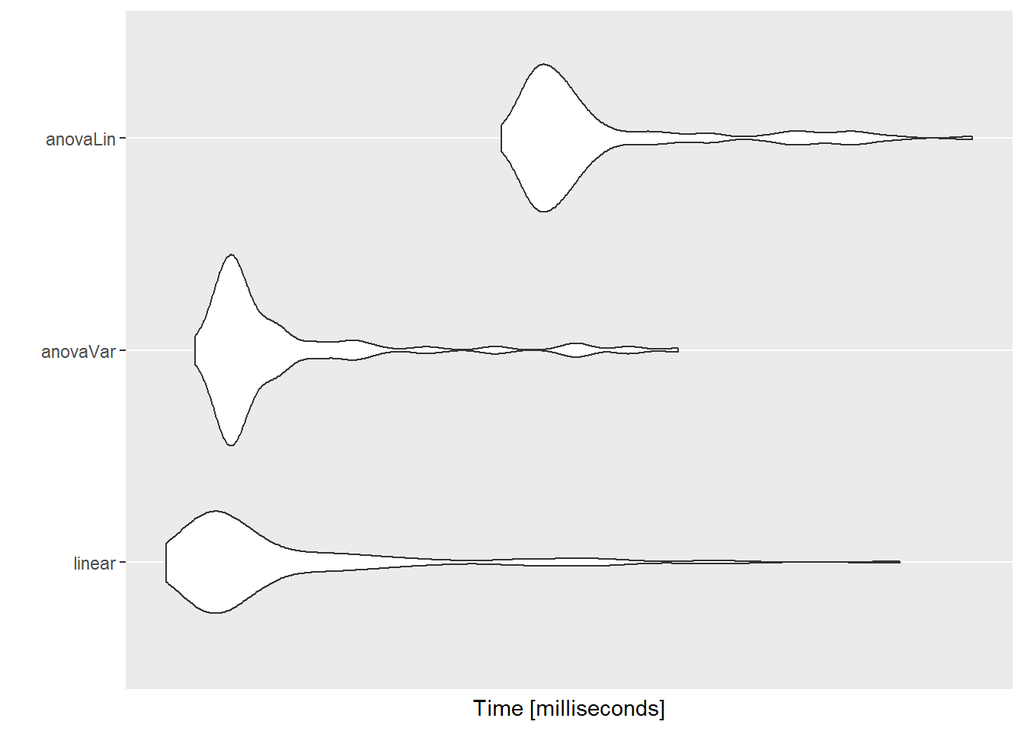

```r
autoplot(etap1)
```

Jak widzimy **aov()** znacznie szybciej wykonuje się od jego odpowiednika. Sprawdźmy jeszcze dodatkowo, jak długo działa anova na dopasowanym juz modelu oraz jak długo wykonuje się **glm()**.

```r
linear = lm(Petal.Length~Species)

anowa <- microbenchmark(
   anovaLin = anova(linear),
   general= glm(Petal.Length~Species)
)
anowa
```

```
## Unit: microseconds
##      expr      min        lq      mean    median       uq      max neval
##  anovaLin  756.093  800.9965  876.0289  820.8825  871.774 3206.979   100
##   general 1225.658 1278.4730 1443.0512 1311.4030 1420.240 4180.320   100
```

### Etap Dwa

Sprawdźmy jeszcze, co wpływa na tak długi czas działania **anova(lm())**.

```r
library(profr)

etap2 <- profr({
   N <- 2000
   df <- as.data.frame(matrix(runif(2*N*N), 2*N, N))
   linear = lm(V1~., data=df)
   anowa = anova(linear)
}, 0.01)
head(etap2)
```

```
##    level g_id t_id                    f start  end n  leaf time source
## 24     1    1    1        as.data.frame  0.01 0.38 1 FALSE 0.37   base
## 25     1    2    1                   lm  0.38 9.31 1 FALSE 8.93  stats
## 26     1    3    1                anova  9.31 9.32 1 FALSE 0.01  stats
## 27     2    1    1               matrix  0.01 0.31 1 FALSE 0.30   base
## 28     2    2    1 as.data.frame.matrix  0.31 0.38 1 FALSE 0.07   base
## 29     2    3    1                 eval  0.38 0.92 1 FALSE 0.54   base
```

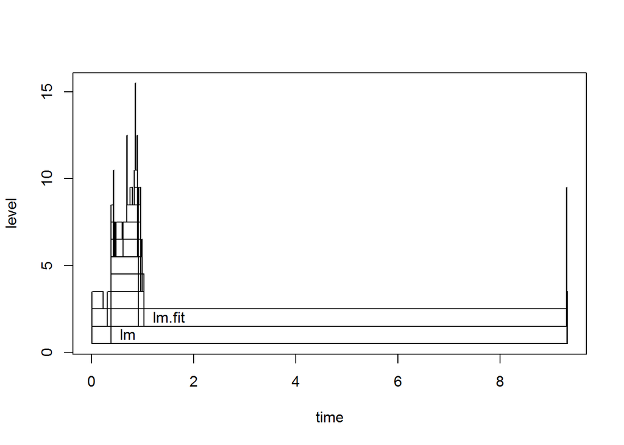

```r
plot(etap2)
```

Widzimy, że bardzo kosztowne czasowo jest dopasowanie modelu liniowego w tym przypadku.